# Grouped summaries with summaries ()

Tetiana Matviichuk

26 06 2020

Loading libraries

```r
library(tidyverse)
library(nycflights13)
```

# How to explore the relationship between the distance and average delay for each location?

There are three steps to prepare this data:

1. Group flights by destination.
2. Summarise to compute distance, average delay, and number of flights.
3. Filter to remove noisy points and Honolulu airport, which is almost twice as far away as the next closest airport.

### summarize() for data frame

It collapses a data frame to a single row:

```r
summarise(flights, delay = mean(dep_delay, na.rm = TRUE))
```

```
## # A tibble: 1 x 1
##   delay
##   <dbl>
## 1  12.6
```

But it is more useful with group_by():

```r
by_day <- group_by(flights, year, month, day)
summarise(by_day, delay = mean(dep_delay, na.rm = TRUE))
```

```
## # A tibble: 365 x 4
## # Groups:   year, month [12]
##     year month   day delay
##    <int> <int> <int> <dbl>
##  1  2013     1     1 11.5
##  2  2013     1     2 13.9
##  3  2013     1     3 11.0
##  4  2013     1     4  8.95
##  5  2013     1     5  5.73
##  6  2013     1     6  7.15
##  7  2013     1     7  5.42
##  8  2013     1     8  2.55
##  9  2013     1     9  2.28
## 10  2013     1    10  2.84
## # ... with 355 more rows
```

### Combining multiple operations with the pipe

```r
by_dest <- flights %>%
        group_by(dest) %>%
        summarise(
                  count = n(),
                  dist = mean(distance, na.rm = TRUE),
                  delay = mean(arr_delay, na.rm = TRUE)
                  ) %>%
        filter(count > 20, dest != "HNL")  #to ignore data with small observations
```

### Presenting plot.

It looks like delays increase with distance up to ~750 miles and then decrease. Maybe as flights get longer there’s more ability to make up delays in the air?

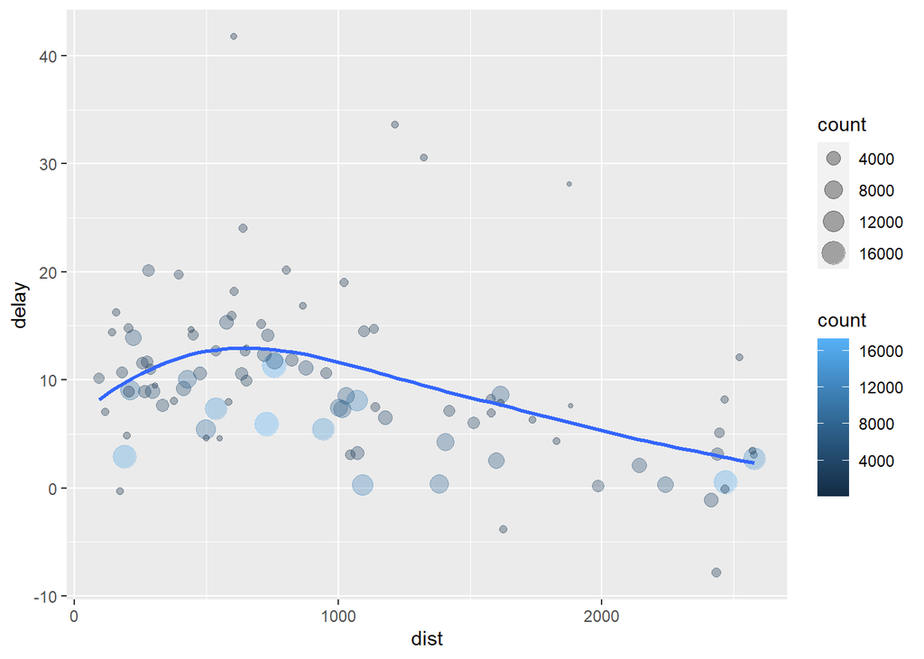

```r
ggplot(data = by_dest, mapping = aes(x = dist, y = delay)) +
        geom_point(aes(size = count, color = count), alpha = 1/3) +
        geom_smooth(se = FALSE)
```

## Missing Values

We could also tackle the problem by first removing the cancelled flights.

```r
not_cancelled <- flights %>%
  filter(!is.na(dep_delay), !is.na(arr_delay))

not_cancelled %>%
  group_by(year, month, day) %>%
  summarise(mean = mean(dep_delay))
```

```
## # A tibble: 365 x 4
## # Groups:   year, month [12]
##     year month   day  mean
##    <int> <int> <int> <dbl>
##  1  2013     1     1 11.4
##  2  2013     1     2 13.7
##  3  2013     1     3 10.9
##  4  2013     1     4  8.97
##  5  2013     1     5  5.73
##  6  2013     1     6  7.15
##  7  2013     1     7  5.42
##  8  2013     1     8  2.56
##  9  2013     1     9  2.30
## 10  2013     1    10  2.84
## # ... with 355 more rows
```

How many are cancelled flights?

```r
cancelled <- flights %>%
        filter(is.na(dep_delay), is.na(arr_delay))
cancelled[which(cancelled$dep_delay == FALSE), ]
```

```
## # A tibble: 0 x 19
## # ... with 19 variables: year <int>, month <int>, day <int>, dep_time <int>,
## #   sched_dep_time <int>, dep_delay <dbl>, arr_time <int>,
## #   sched_arr_time <int>, arr_delay <dbl>, carrier <chr>, flight <int>,
## #   tailnum <chr>, origin <chr>, dest <chr>, air_time <dbl>, distance <dbl>,
## #   hour <dbl>, minute <dbl>, time_hour <dttm>
```

```r
cancelled %>%
        group_by(tailnum) %>%
        summarise(
                count = n()
                )
```

```
## # A tibble: 1,450 x 2
##    tailnum count
##    <chr>   <int>
##  1 N0EGMQ     17
##  2 N10156      7
##  3 N10575     17
##  4 N11106      3
##  5 N11107      8
##  6 N11109      5
##  7 N11113     12
##  8 N11119     10
##  9 N11121      6
## 10 N11127      5
## # ... with 1,440 more rows
```

### Counts

Whenever you do any aggregation, it’s always a good idea to include either a count (n()), or a count of non-missing values (sum(!is.na(x))). That way you can check that you’re not drawing conclusions based on very small amounts of data.

```r
delays <- flights %>%
        group_by(tailnum) %>%
        summarise(
                delay = mean(arr_delay)
        )
head(delays, 20)
```

```
## # A tibble: 20 x 2
##    tailnum  delay
##    <chr>    <dbl>
##  1 D942DN  31.5
##  2 N0EGMQ  NA
##  3 N10156  NA
##  4 N102UW   2.94
##  5 N103US  -6.93
##  6 N104UW  NA
##  7 N10575  NA
##  8 N105UW  -0.267
##  9 N107US  -5.73
## 10 N108UW  -1.25
## 11 N109UW  -2.52
## 12 N110UW   2.8
## 13 N11106  NA
## 14 N11107  NA
## 15 N11109  NA
## 16 N11113  NA
## 17 N11119  NA
## 18 N11121  NA
## 19 N11127  NA
## 20 N11137  NA
```

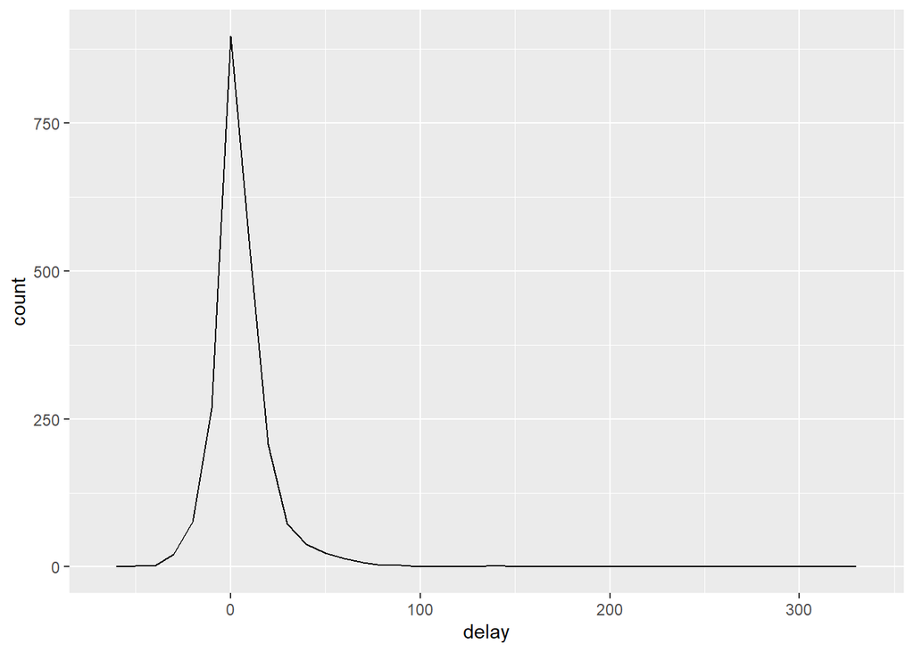

```r
ggplot(data = delays, mapping = aes(x = delay)) +
        geom_freqpoly(binwidth = 10)
```

But we can get more insight if we draw a scatterplot of number of flights vs. average delay:

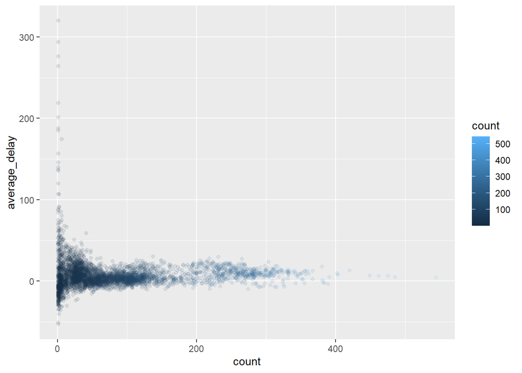

```r
delays <- not_cancelled%>%
  group_by(tailnum) %>%
  summarise(
    count = n(),
    average_delay = mean(arr_delay, na.rm= TRUE)
  )

ggplot(data = delays, mapping = aes(x = count, y = average_delay)) +
  geom_point(aes(color = count), alpha = 1/10)
```

When looking at this sort of plot, it’s often useful to filter out the groups with the smallest numbers of observations, so you can see more of the pattern and less of the extreme variation in the smallest groups.

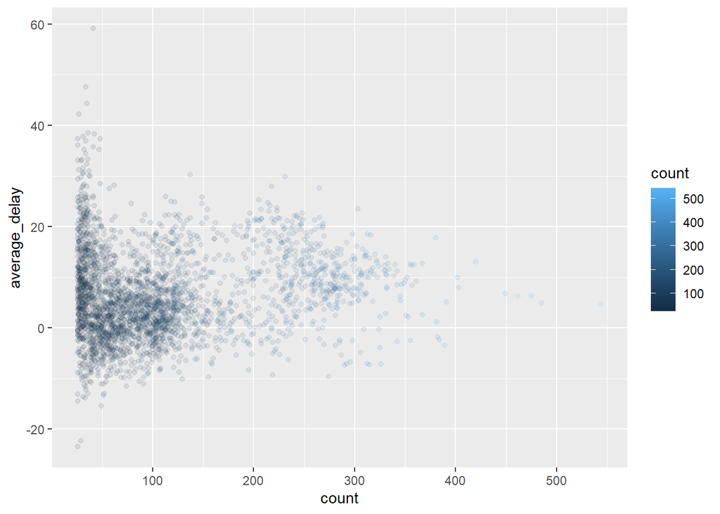

```r
delays %>%
  filter(count > 25) %>%
  ggplot(mapping = aes(x = count, y = average_delay)) +
  geom_point(aes(color = count), alpha = 1/10)
```

**RStudio tip**: a useful keyboard shortcut is **Cmd/Ctrl + Shift + P**. This resends the previously sent chunk from the editor to the console.

## Example on Lahman database

There’s another common variation of this type of pattern. Let’s look at how the average performance of batters in baseball is related to the number of times they’re at bat.

We will compute the batting average (number of hits / number of attempts) of every major league baseball player.

When plotting the skill of the batter (measured by the batting average, *ba*) against the number of opportunities to hit the ball (measured by at bat, *ab*), see two patterns:

1. As above, the variation in our aggregate decreases as we get more data points.
2. There’s a positive correlation between skill (ba) and opportunities to hit the ball (ab). This is because teams control who gets to play, and obviously they’ll pick their best players.

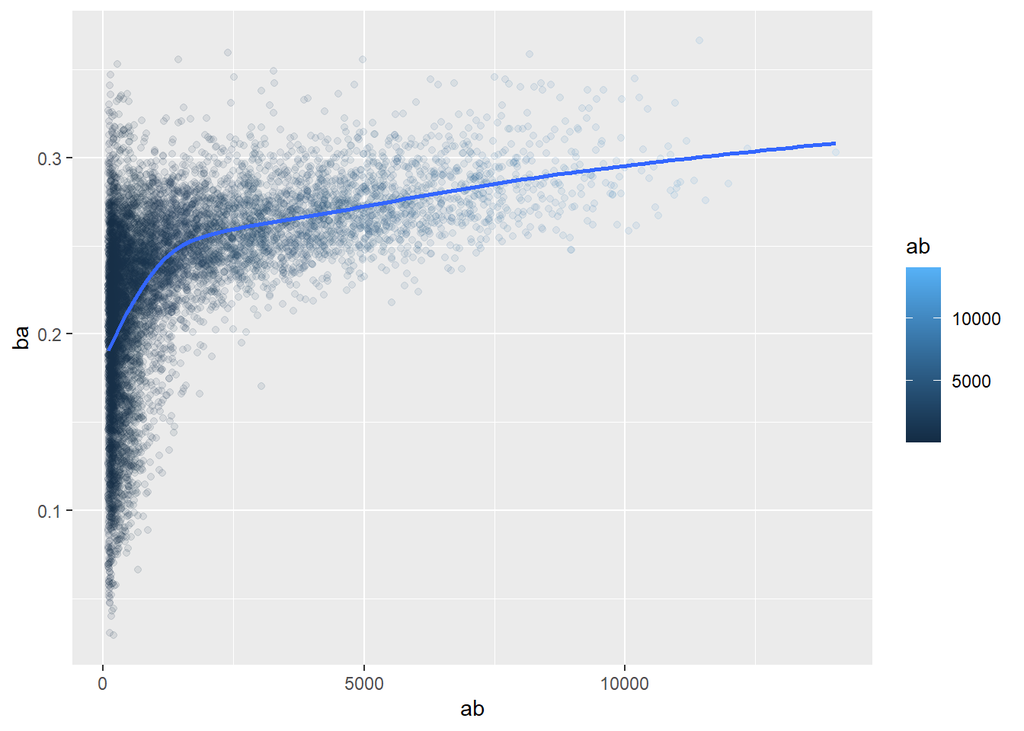

```r
library(Lahman)
library(dplyr)

batting <- Lahman::Batting
batters <- batting %>%
  group_by(playerID) %>%
  summarise(
    ba = sum(H, na.rm = T)/sum(AB, na.rm = T),
    ab = sum(AB, na.rm = T)
  )

batters %>%
  filter(ab > 100) %>%
  ggplot(mapping = aes(x = ab, y = ba)) +
  geom_point(aes(color = ab), alpha = 1/10) +
  geom_smooth(se = FALSE)
```

## Useful summary function

Except of sum(x), mean(x), counts, there are:

- **Measures of location**: *the median* - is a value where 50% of x is above it, and 50% is below it.
- **Measures of spread**: sd(x), IQR(x), mad(x). *The root mean squared deviation*, or standard deviation *sd(x)*, is the standard measure of spread. *The interquartile range IQR(x)* and *median absolute deviation mad(x)* are robust equivalents that may be more useful if you have outliers
- **Measures of rank**: *min(x), quantile(x, 0.25), max(x)*. Quantiles are a generalisation of the median. For example, quantile(x, 0.25) will find a value of x that is greater than 25% of the values, and less than the remaining 75%.
- **Measures of position**: first(x), nth(x, 2), last(x). These work similarly to x[1], x[2], and x[length(x)]

```r
not_cancelled %>%
  group_by(year, month, day) %>%
  summarise(
    first_dep = first(dep_time),
    last_dep = last(dep_time)
  )
```

```
## # A tibble: 365 x 5
## # Groups:   year, month [12]
##     year month   day first_dep last_dep
##    <int> <int> <int>     <int>    <int>
##  1  2013     1     1       517     2356
##  2  2013     1     2        42     2354
##  3  2013     1     3        32     2349
##  4  2013     1     4        25     2358
##  5  2013     1     5        14     2357
##  6  2013     1     6        16     2355
##  7  2013     1     7        49     2359
##  8  2013     1     8       454     2351
##  9  2013     1     9         2     2252
## 10  2013     1    10         3     2320
## # ... with 355 more rows
```

```
    These functions are complementary to filtering on ranks. Filtering gives you all variables, with each observation in a separate row:
```

```r
not_cancelled %>%
  group_by(year, month, day) %>%
  mutate(r = min_rank(desc(dep_time))) %>%
  filter(r %in% range(r))
```

```
## # A tibble: 770 x 20
## # Groups:   year, month, day [365]
##     year month   day dep_time sched_dep_time dep_delay arr_time sched_arr_time
##    <int> <int> <int>    <int>          <int>     <dbl>    <int>          <int>
##  1  2013     1     1      517            515         2      830            819
##  2  2013     1     1     2356           2359        -3      425            437
##  3  2013     1     2       42           2359        43      518            442
##  4  2013     1     2     2354           2359        -5      413            437
##  5  2013     1     3       32           2359        33      504            442
##  6  2013     1     3     2349           2359       -10      434            445
##  7  2013     1     4       25           2359        26      505            442
##  8  2013     1     4     2358           2359        -1      429            437
##  9  2013     1     4     2358           2359        -1      436            445
## 10  2013     1     5       14           2359        15      503            445
## # ... with 760 more rows, and 12 more variables: arr_delay <dbl>,
## #   carrier <chr>, flight <int>, tailnum <chr>, origin <chr>, dest <chr>,
## #   air_time <dbl>, distance <dbl>, hour <dbl>, minute <dbl>, time_hour <dttm>,
## #   r <int>
```

- **Counts**: n() - which takes no arguments, and returns the size of the current group. To count the number of non-missing values, use sum(!is.na(x)). To count the number of distinct (unique) values, use n_distinct(x).

```r
# Which destinations have the most carriers?
not_cancelled %>%
  group_by(dest) %>%
  summarise(carriers = n_distinct(carrier)) %>%
  arrange(desc(carriers))
```

```
## # A tibble: 104 x 2
##    dest  carriers
##    <chr>    <int>
##  1 ATL          7
##  2 BOS          7
##  3 CLT          7
##  4 ORD          7
##  5 TPA          7
##  6 AUS          6
##  7 DCA          6
##  8 DTW          6
##  9 IAD          6
## 10 MSP          6
## # ... with 94 more rows
```

```
    Counts are so useful that dplyr provides a simple helper if all you want is a count:
```

```r
not_cancelled %>%
  count(dest)
```

```
## # A tibble: 104 x 2
##    dest      n
##    <chr> <int>
##  1 ABQ     254
##  2 ACK     264
##  3 ALB     418
##  4 ANC       8
##  5 ATL   16837
##  6 AUS    2411
##  7 AVL     261
##  8 BDL     412
##  9 BGR     358
## 10 BHM     269
## # ... with 94 more rows
```

```
    You can optionally provide a weight variable. For example, you could use this to “count” (sum) the total number of miles a plane flew:
```

```r
not_cancelled %>%
  count(tailnum, wt = distance)
```

```
## # A tibble: 4,037 x 2
##    tailnum      n
##    <chr>    <dbl>
##  1 D942DN    3418
##  2 N0EGMQ  239143
##  3 N10156  109664
##  4 N102UW   25722
##  5 N103US   24619
##  6 N104UW   24616
##  7 N10575  139903
##  8 N105UW   23618
##  9 N107US   21677
## 10 N108UW   32070
## # ... with 4,027 more rows
```

- **Counts and proportions of logical values**: sum(x > 10), mean(y == 0). When used with numeric functions, TRUE is converted to 1 and FALSE to 0. This makes sum() and mean() very useful: sum(x) gives the number of TRUEs in x, and mean(x) gives the proportion.

```r
# How many flights left before 5am? (these usually indicate delayed
# flights from the previous day)
not_cancelled %>%
  group_by(year, month, day) %>%
  summarise(n_early = sum(dep_time < 500))
```

```
## # A tibble: 365 x 4
## # Groups:   year, month [12]
##     year month   day n_early
##    <int> <int> <int>   <int>
##  1  2013     1     1       0
##  2  2013     1     2       3
##  3  2013     1     3       4
##  4  2013     1     4       3
##  5  2013     1     5       3
##  6  2013     1     6       2
##  7  2013     1     7       2
##  8  2013     1     8       1
##  9  2013     1     9       3
## 10  2013     1    10       3
## # ... with 355 more rows
```

```r
# What proportion of flights are delayed by more than an hour?
not_cancelled %>%
  group_by(year, month, day) %>%
  summarise(hour_prop = mean(arr_delay > 60))
```

```
## # A tibble: 365 x 4
## # Groups:   year, month [12]
##     year month   day hour_prop
##    <int> <int> <int>     <dbl>
##  1  2013     1     1    0.0722
##  2  2013     1     2    0.0851
##  3  2013     1     3    0.0567
##  4  2013     1     4    0.0396
##  5  2013     1     5    0.0349
##  6  2013     1     6    0.0470
##  7  2013     1     7    0.0333
##  8  2013     1     8    0.0213
##  9  2013     1     9    0.0202
## 10  2013     1    10    0.0183
## # ... with 355 more rows
```

## Grouping by multiple variables

When you group by multiple variables, each summary peels off one level of the grouping. That makes it easy to progressively roll up a dataset:

```r
daily <- group_by(flights, year, month, day)
(per_day   <- summarise(daily, flights = n()))
```

```
## # A tibble: 365 x 4
## # Groups:   year, month [12]
##     year month   day flights
##    <int> <int> <int>   <int>
##  1  2013     1     1     842
##  2  2013     1     2     943
##  3  2013     1     3     914
##  4  2013     1     4     915
##  5  2013     1     5     720
##  6  2013     1     6     832
##  7  2013     1     7     933
##  8  2013     1     8     899
##  9  2013     1     9     902
## 10  2013     1    10     932
## # ... with 355 more rows
```

```r
(per_month <- summarise(per_day, flights = sum(flights)))
```

```
## # A tibble: 12 x 3
## # Groups:   year [1]
##     year month flights
##    <int> <int>   <int>
##  1  2013     1   27004
##  2  2013     2   24951
##  3  2013     3   28834
##  4  2013     4   28330
##  5  2013     5   28796
##  6  2013     6   28243
##  7  2013     7   29425
##  8  2013     8   29327
##  9  2013     9   27574
## 10  2013    10   28889
## 11  2013    11   27268
## 12  2013    12   28135
```

```r
(per_year <- summarise(per_month, flights = sum(flights)))
```

```
## # A tibble: 1 x 2
##    year flights
##   <int>   <int>
## 1  2013  336776
```

It’s OK for sums and counts - the sum of groupwise sums is the overall sum, but the median of groupwise medians is not the overall median.

## Ungrouping

```r
daily %>%
  ungroup() %>%             # no longer grouped by date
  summarise(flights = n())  # all flights
```

```
## # A tibble: 1 x 1
##   flights
##     <int>
## 1  336776
```